# Home Work Data Viz Live 01

tamakuku

2024-01-09

### 1. plot 5 chart with mpg dataframe

### 2. write document in markdown

### 3. explain what insight we got from each chart.

## **install packages and call library must using**

```r
install.packages("ggplot2")
install.packages("tidyverse")

library(ggplot2)
library(tidyverse)
```

## **Chart 1**. Bar plot >>> to find the popular model produced by Ford’s cars.

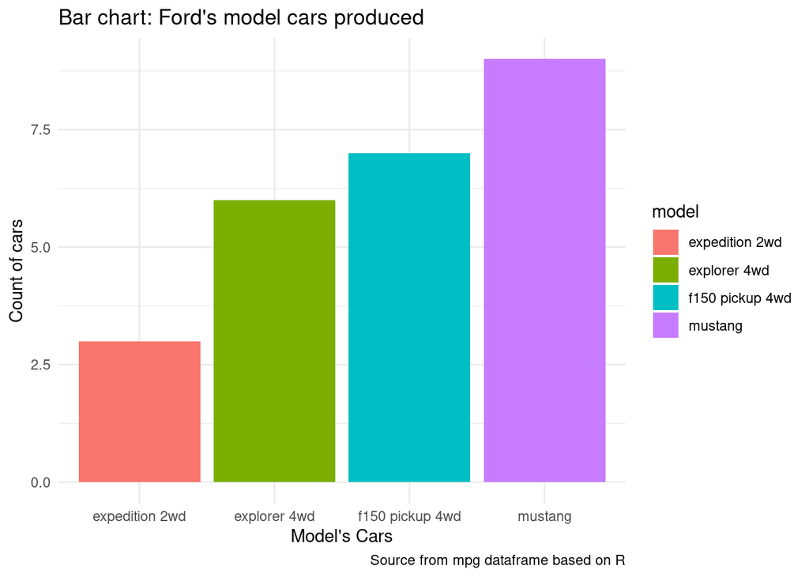

```r
ggplot( mpg %>%
          filter( manufacturer
 == "ford" ), aes( x = model, fill = model ) ) +
          geom_bar() +
          theme_minimal() +
          labs( title = "Bar chart: Ford's model cars produced",
                x = "Model's Cars",
                y = "Count of cars",
                caption = "Source from mpg dataframe based on R")
```

### *insight : The Mustang is the most popular model car produced by Ford’s manufacturer.*

## **Chart 2.** Histogram plot >>> to Segment ‘displ’ (or engine displacement, in liters) of cars was produced.

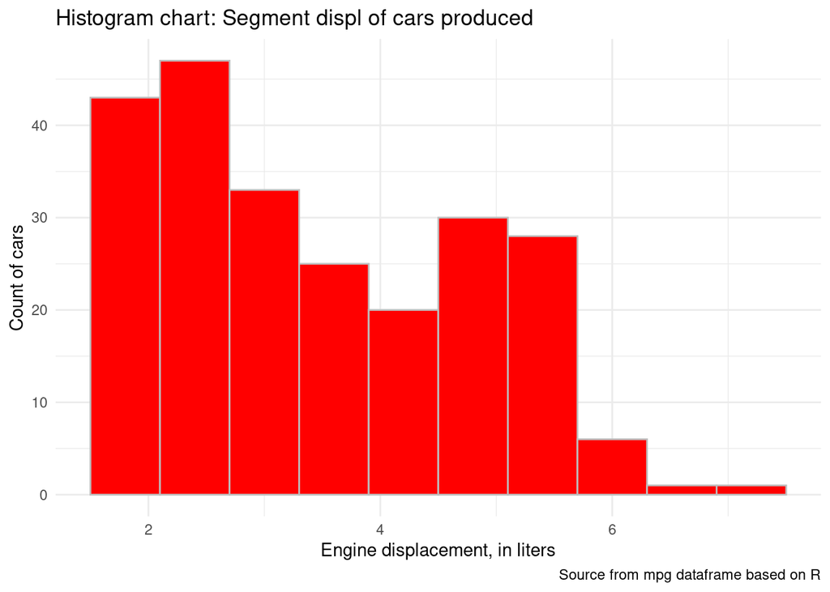

```r
ggplot( mpg, aes( x = displ ) ) +
          geom_histogram( bins = 10, fill = "red", col = "grey") +
          theme_minimal() +
          labs( title = "Histogram chart: Segment displ of cars produced",
                x = "Engine displacement, in liters",
                y = "Count of cars",
                caption = "Source from mpg dataframe based on R" )
```

### *insight: If a car’s have ‘displ’(or engine displacement) more than 6 liters, it is less was produced.*

## **Chart 3.** Scatter plot >>> to find a relationship between ‘displ’(or engine displacement, in liters) and ‘cty’(or city distance, in miles per gallon).

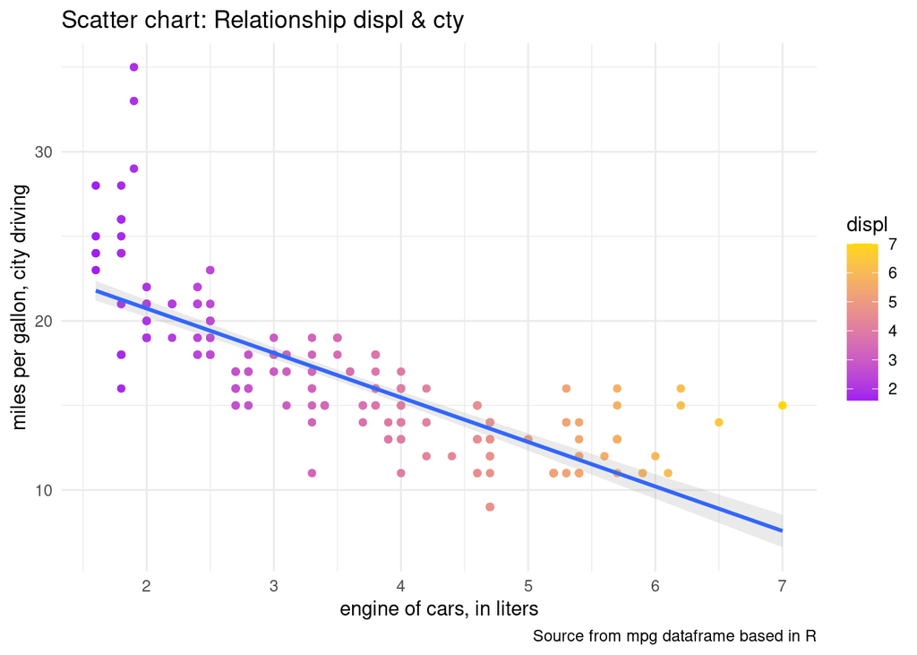

```r
ggplot( mpg, aes( x = displ, y = cty, color = displ) ) +
          geom_point() +
          geom_smooth( method = "lm", alpha = 0.2 ) +
          scale_color_gradient( low = "purple", high = "gold") +
          theme_minimal() +
          labs( title = "Scatter chart: Relationship displ & cty",
                x = "engine of cars, in liters",
                y = "miles per gallon, city driving",
                caption = "Source from mpg dataframe based in R" )
```

### *insight: If a car’s ‘displ’(or engine displacement) has more liters, it can drive less distance in the city.*

## **Chart 4.** Scatter plot by 2 data.frame >>> to compare Ford and Audi by auto gear, which one can drive long distances on highways?

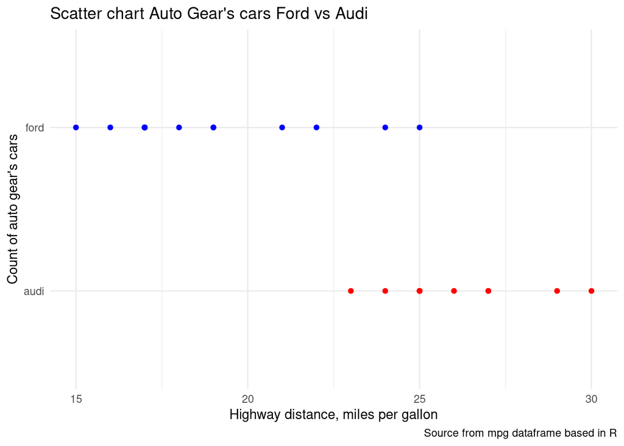

```r
ford_auto <- mpg %>%
              select( manufacturer, trans, hwy ) %>%
              filter( manufacturer == "ford" & grepl( "auto", mpg$trans ) )
audi_auto <- mpg %>%
              select( manufacturer, trans, hwy ) %>%
              filter( manufacturer == "audi" & grepl( "auto", mpg$trans ) )

ggplot() +
  geom_point( data = ford_auto, aes( x = hwy , y = manufacturer ), color = "blue" ) +
  geom_point( data = audi_auto, aes( x = hwy , y = manufacturer ), color = "red" ) +
  theme_minimal() +
  labs( title = "Scatter chart Auto Gear's cars Ford vs Audi",
        x = "Highway distance, miles per gallon",
        y = "Count of auto gear's cars",
        caption = "Source from mpg dataframe based in R")
```

### *insight: When comparing two manufacturer’s cars with auto gear, Audi can drive on the highway for more distance than Ford.*

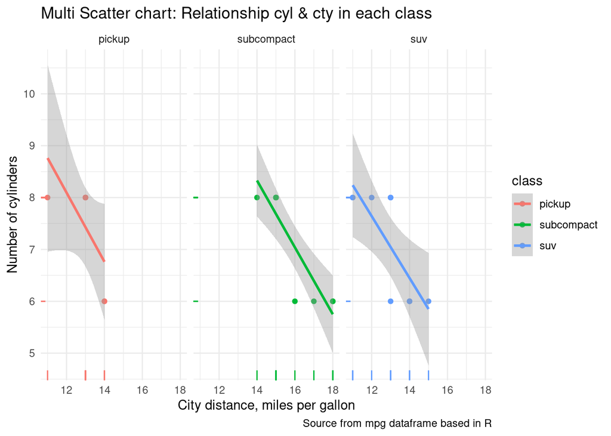

```r
ggplot( mpg  %>%
          filter( manufacturer == "ford"),
        aes( x = cty, y = cyl, color = class) ) +
  geom_point() +
  geom_smooth( method = "lm") +
  geom_rug() +
  facet_grid( ~class ) +
  theme_minimal() +
  labs( title = "Multi Scatter chart: Relationship cyl & cty in each class",
        x = "City distance, miles per gallon",
        y = "Number of cylinders",
        caption = "Source from mpg dataframe based in R")
```